# Pilot Test Notebook

Do Won Kim

2023-08-09

# Summary Note

Main goal: to figure out what accounts the participants are following

- Reverse chronological is only practical way

Problem: Reverse chronological endpoint is capped (limited 10k tweets/month)

- So could we fit the Pro access limit (1M)?

To get a sense of this, we are analyzing Rockwell pilot data and trying to estimate…

- How long does it take for us to get 1M (how many pulls/tweets to collect for me to have a sense of the unique accounts these people are following)? When do we reach a good point that an additional pull is not worth it (where we could stop pulling)?

Strategy:

- X: number of tweets collected
- Y: fraction of distinct accounts appearing in these tweets pulled

⟹ See where the plot becomes flat (find the elbow point/saturating point)

# What major changes have been made?

1. As Brendan suggested in the last meeting, a new way of calculating the y-axis (= fraction of distinct accounts appearing in tweets collected) is added.
   - old: `# of distinct accounts appearing in tweets` / `total # of distinct friends that each user has`.
   - new: `# of distinct accounts appearing in tweets` / `total # of distinct accounts that each user sees`.
2. In the last meeting, the x-axis was `# of tweets collected` in all plots. However, the problem is that this x-axis is not comparable across users since they have different number of friends - e.g. some users follow lots of friends thus naturally, they get more number of tweets; some others follow only few accounts thereby getting few number of tweets. Since the y-axis is in fraction/relative terms, the new rescaled x-axis is also added.
   - Rescaling method: divide x-axis (`# of tweets collected`) by the average tweets per second of each user.
     - Meaning of the rescaled x-axis: the time it takes to observe a fraction of friends in the timeline

```r
# Load packages
library(readr)
library(tidyverse)
library(ggplot2)
library(ggthemes)
library(grid)
library(gridExtra)
library(DT)
library(lubridate)
library(scales)
library(dplyr)
library(magrittr)
```

```r
#**** Prepare data ****#
# Load data
# The data is cleaned and exported using Python.
# Python code for making dataframe for R is provided upon request.
df <- read_csv("df.csv")
backup <- df
# Define data type
df %>%
  mutate(
    user_id = as.factor(user_id),
    tweet_id = as.factor(tweet_id),
    friend_id = as.factor(account_id)
  ) %>%
  dplyr::select(-account_id) -> df


# Making new variables
# (1) Maximum number of each user's friends: max_friends_count
# What is the maximum of user_friends_count?
df %>%
  dplyr::select(user_id, user_friends_count) %>%
  distinct() %>%
  group_by(user_id) %>%
  mutate(max_friends_count = max(user_friends_count)) %>%
  dplyr::select(-user_friends_count) %>%
  distinct() -> max_data
# max_data: a new dataframe with `user_id` and `max_friends_count` as variables

# Merge this 'max_data' into df
df %>%
  merge(max_data, by="user_id") -> df

# (2) Timestamp data of each tweet: tweet_timestamp
# Let's clean timestamp data to have affinity with R lubridate pacakge

list_timestamp <- str_split(df$tweet_timestamp, " ")  # make a list containing each string component of timestamp data

Month = c()  # make an empty vector
Day = c()
Time = c()
Year = c()
timestamp_dmyt = c()

# fill these vectors with month, day, time, year components within each list element
for (i in 1:length(list_timestamp)) {
  list_timestamp[[i]][2] -> Month[i]
  list_timestamp[[i]][3] -> Day[i]
  list_timestamp[[i]][4] -> Time[i]
  list_timestamp[[i]][6] -> Year[i]
  }

timestamp_dmyt = as.data.frame(cbind(Day, Month, Year, Time)) # bind these filled vectors and make it as a dataframe; store this dataframe as 'timestamp_dmyt'

# now paste the strings into one and store them in a vector 'dmyt'
dmyt = c()
for (i in 1:nrow(timestamp_dmyt)) {
  dmyt[i] = paste(Day[i], Month[i], Year[i], Time[i])
}

# make 'dmyt' vector as a new variable of dataframe: 'tweet_timestamp'
df$tweet_timestamp = dmy_hms(dmyt)  # timestamp format: day-month-year-hour-minute-second

# (3) Define x-axis: number of tweets collected
df %>%
  arrange(tweet_timestamp) %>%  # arrange the data by time
  group_by(user_id) %>%
  count(tweet_id) %>%
  mutate(
    old_x = cumsum(n),  # old_x: number of tweets collected so far
    max_n_tweets = max(old_x)
  ) %>%
  dplyr::select(
    user_id, tweet_id, old_x, max_n_tweets
  ) -> df_for_x

df %>%
  inner_join(df_for_x, by=c("user_id", "tweet_id")) %>%
  arrange(user_id, tweet_timestamp) -> df

#* [X] Re-scaling → divide x axis by the average tweets per second of each participant.
#* For each participant, (1) take the first and last tweet in the data and compute the number of seconds between them, and then (2) divide the total number of tweets seen for the participant by the number of seconds.

df |>
  group_by(user_id) |>
  summarise(timediff = max(tweet_timestamp) - min(tweet_timestamp)) -> timeDiff

df |>
  merge(timeDiff, by="user_id") |>
  group_by(user_id) |>
  mutate(
    avg_n_tweets_persec = max_n_tweets / as.numeric(timediff)
  ) |>
  ungroup() |>
  mutate(
    new_x = old_x / avg_n_tweets_persec # new_x: number of tweets collected so far divided by the average number of tweets per seconds
    ) -> df2

# (4) Define y-axis: count how many distinct accounts are in the tweets (numerator)
#* [Y] Re-scaling → make a fraction for y-axis (new denominator as Brendan suggested : maximum of the total distinct accounts you "see" (not you have) as a new denominator to make all 60 indviduals reach 1 in the end (individual plots))

df2 %>%
  arrange(user_id, tweet_timestamp) %>%
  group_by(user_id) %>%
  mutate(
    numerator = cumsum(!duplicated(friend_id)),
    old_y = numerator / max_friends_count,
    new_y =  numerator / max(numerator)
  ) -> df2

# df2 is the final data for drawing plots
```

Changes made to the x- and y-axes are described in this table.

[output not shown]

*※ This is the short version notebook so plot notation is a little bit unorganized*

# Plot 1.

- Plots 1a and 1b to show the effect of Brendan’s idea

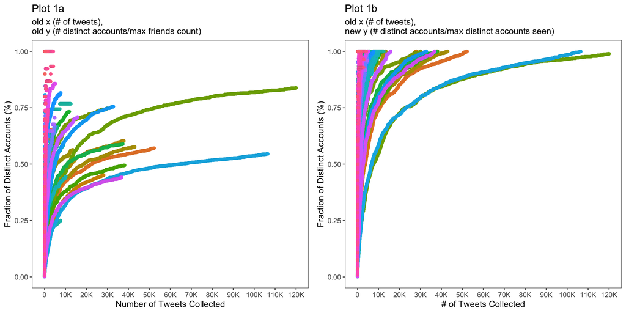

```r
df2 %>%
  group_by(user_id) %>%
  ggplot(aes(x=old_x, y=old_y, col=user_id)) +
  geom_point(alpha=0.5) +
  theme_few() +
  theme(legend.position="none") +
  xlab("Number of Tweets Collected") +
  ylab("Fraction of Distinct Accounts (%)") +
  scale_x_continuous(n.breaks = 10, limits=c(0, 120000),
                     labels = label_number(scale_cut = cut_short_scale())) +
  ggtitle("Plot 1a", subtitle = "old x (# of tweets), \nold y (# distinct accounts/max friends count)") -> plot1a

df2 %>%
  group_by(user_id) %>%
  ggplot(aes(x=old_x, y=new_y, col=user_id)) +
  geom_point(alpha=0.5) +
  theme_few() +
  theme(legend.position="none") +
  xlab("# of Tweets Collected") +
  ylab("Fraction of Distinct Accounts (%)") +
  scale_x_continuous(n.breaks = 10, limits=c(0, 120000),
                     labels = label_number(scale_cut = cut_short_scale())) +
  ggtitle("Plot 1b", subtitle = "old x (# of tweets), \nnew y (# distinct accounts/max distinct accounts seen)") -> plot1b


grid.arrange(plot1a, plot1b, nrow=1)
```

# Plot 2.

- Plots 2e and 2f to show the effect of rescaling to see if there is a collapse

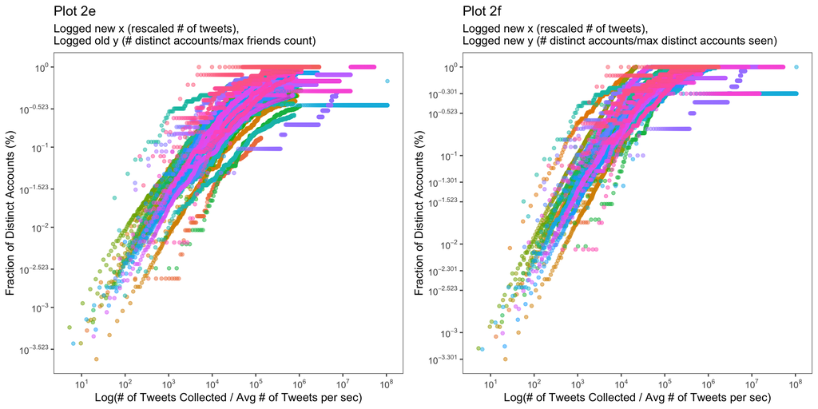

```r
df2 %>%
  group_by(user_id) %>%
  ggplot(aes(x=new_x, y=old_y, col=user_id)) +
  geom_point(alpha=0.5) +
  theme_few() +
  theme(legend.position="none") +
  xlab("# of Tweets Collected / Avg # of Tweets per sec") +
  ylab("Fraction of Distinct Accounts (%)") +
  scale_x_continuous(n.breaks = 10, limits = c(0, 30000000),
                     labels = label_number(scale_cut = cut_short_scale())) +
  ggtitle("Plot 1c", subtitle = "new x (rescaled # of tweets), \nold y (# distinct accounts/max friends count)") -> plot1c

plot1c +
  xlab("Log(# of Tweets Collected / Avg # of Tweets per sec)") +
  scale_x_log10(n.breaks=10,
                labels = scales::label_log()) +
  ggtitle("Plot 2c", subtitle = "Logged new x (rescaled # of tweets), \nold y (# distinct accounts/max friends count)") -> plot2c


df2 %>%
  group_by(user_id) %>%
  ggplot(aes(x=new_x, y=new_y, col=user_id)) +
  geom_point(alpha=0.5) +
  theme_few() +
  theme(legend.position="none") +
  xlab("# of Tweets Collected / Avg # of Tweets per sec") +
  ylab("Fraction of Distinct Accounts (%)") +
  scale_x_continuous(n.breaks = 10, limits = c(0, 30000000),
                     labels = label_number(scale_cut = cut_short_scale())) +
  ggtitle("Plot 1d", subtitle = "new x (rescaled # of tweets), \nnew y (# distinct accounts/max distinct accounts seen)") -> plot1d

plot1d +
  xlab("Log(# of Tweets Collected / Avg # of Tweets per sec)") +
  scale_x_log10(n.breaks=10,
                 labels = scales::label_log()) +
  ggtitle("Plot 2d", subtitle = "Logged new x (rescaled # of tweets), \nnew y (# distinct accounts/max distinct accounts seen)") -> plot2d


plot1c +
  xlab("Log(# of Tweets Collected / Avg # of Tweets per sec)") +
  scale_x_log10(n.breaks=10,
                labels = scales::label_log()) +
  ggtitle("Plot 2c", subtitle = "Logged new x (rescaled # of tweets), \nold y (# distinct accounts/max friends count)") -> plot2c

plot2c +
  scale_y_log10(n.breaks=10,  labels = scales::label_log()) +
  ggtitle("Plot 2e", subtitle = "Logged new x (rescaled # of tweets), \nLogged old y (# distinct accounts/max friends count)") -> plot2e

plot1d +
  xlab("Log(# of Tweets Collected / Avg # of Tweets per sec)") +
  scale_x_log10(n.breaks=10,
                 labels = scales::label_log()) +
  ggtitle("Plot 2d", subtitle = "Logged new x (rescaled # of tweets), \nnew y (# distinct accounts/max distinct accounts seen)") -> plot2d

plot2d +
  scale_y_log10(n.breaks=10,  labels = scales::label_log()) +
  ggtitle("Plot 2f", subtitle = "Logged new x (rescaled # of tweets), \nLogged new y (# distinct accounts/max distinct accounts seen)") -> plot2f

grid.arrange(plot2e, plot2f, ncol=2)
```

# Aggregate Plots

What if we aggregate users by taking the mean of fraction of distinct accounts (=y) at each point of the tweets collected (=x)?

- Hence, in the aggregate plots, the y-axis indicates the mean fraction of distinct accounts that users see for each (cumulative) number of tweets collected.

For plots with the rescaled x-axis (= `# of tweets/avg # of tweets per sec`), I applied **logarithmic** **binning** on the x-axis and then calculated weighted average of y.

- This is due to the fact that `avg # of tweets per sec` is highly distinct among users thus making it almost useless to group by each point at the x-axis and summarizing the mean value of y.
- Now that the same bin may contain multiple observations of the same user, or that some users may not appear at all in certain bins, I apply weighted average where each user is weighted by the number of observation in each bin.

```r
# Logarithmic Binning
# for the labels:
unlist(lapply(c(2^(1:30)), label_math(2^.x, format = log))) -> labels_list
labels_vector = c()
for (i in 1:length(labels_list)) {
  labels_vector[i] = unlist(str_split(as.character(labels_list[i]), "\\."))[1] }

df2 %>%
  mutate(
    bins = cut(new_x ,
               breaks = c(1,2^(1:30)),
               labels = c(paste0('<=',labels_vector)),
               include.lowest = TRUE)) %>%
  group_by(user_id, bins) %>%
  mutate(weights = n()) %>%
  ungroup() %>%
  group_by(bins) %>%
  summarise(old_y_weighted = weighted.mean(old_y, weights),
         new_y_weighted = weighted.mean(new_y, weights)) %>%
  ungroup() -> df3
```

# Plot 4. Aggregate Plots with Logarithmic Scales

- Plots 4b and 4d to show aggregate results

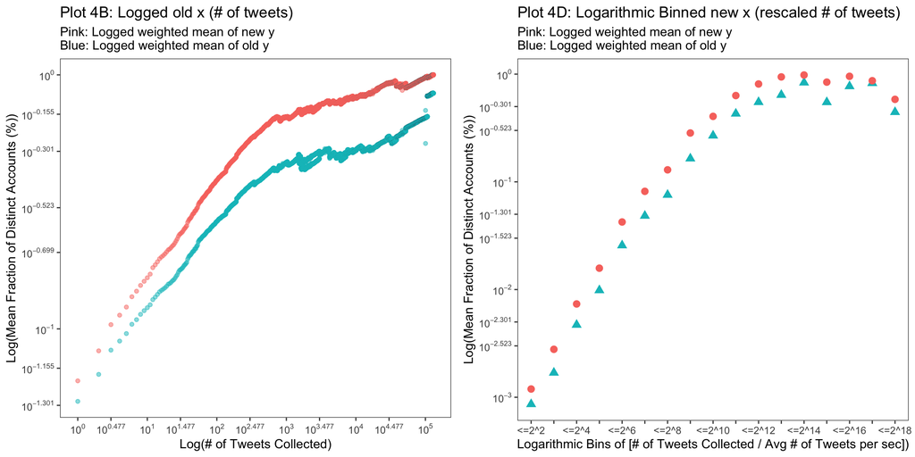

```r
df2 %>%
  group_by(old_x) %>%
  summarize(y_old = mean(old_y), y_new = mean(new_y)) %>%
  ungroup() %>%
  pivot_longer(cols = c("y_old","y_new")) %>%
  ggplot(aes(x=old_x, y=value, col=name)) +
  geom_point(alpha=0.5) +
  theme_few() +
  theme(legend.position="none") +
  xlab("# of Tweets Collected") +
  ylab("Mean Fraction of Distinct Accounts (%)") +
  scale_x_continuous(n.breaks = 10, limits = c(0, 120000),
                     labels = label_number(scale_cut = cut_short_scale())) +
   ylim(c(0, 1)) +
  ggtitle("Plot 3ab: old x (# of tweets)", subtitle = "Pink: mean of new y \nBlue: mean of old y") -> plot3ab


plot3ab +
  xlab("Log(# of Tweets Collected)") +
  scale_x_log10(n.breaks=10,
                labels = scales::label_log()) +
  ggtitle("Plot 4A: Logged old x (# of tweets)",
          subtitle = "Pink: mean of new y \nBlue: mean of old y") -> plot4a

plot4a +
  ylab("Log(Mean Fraction of Distinct Accounts (%))") +
  scale_y_log10(n.breaks=10,  labels = scales::label_log()) +
  ggtitle("Plot 4B: Logged old x (# of tweets)",
          subtitle = "Pink: Logged weighted mean of new y  \nBlue: Logged weighted mean of old y") -> plot4b

df3 %>%
  pivot_longer(cols=c("old_y_weighted", "new_y_weighted")) %>%
  ggplot(aes(x=bins, y=value, col=name)) +
  geom_point(size = 3, aes(shape = name)) +
  theme_few() +
  theme(legend.position="none") +
  ylab("Mean Fraction of Distinct Accounts (%)") +
  ylim(c(0, 1)) +
  xlab("Logarithmic Bins of [# of Tweets Collected / Avg # of Tweets per sec])") +
  scale_x_discrete(guide = guide_axis(check.overlap = T)) +
  ggtitle("Plot 4C: Logarithmic Binned new x (rescaled # of tweets)",
          subtitle = "Pink: weighted mean of new y  \nBlue: weighted mean of old y") -> plot4c

plot4c +
  ylab("Log(Mean Fraction of Distinct Accounts (%))") +
  scale_y_log10(n.breaks=10,  labels = scales::label_log()) +
  ggtitle("Plot 4D: Logarithmic Binned new x (rescaled # of tweets)",
          subtitle = "Pink: Logged weighted mean of new y  \nBlue: Logged weighted mean of old y") -> plot4d

grid.arrange(plot4b, plot4d, ncol=2)
```

# [Additional Note] Low quality sources

I merged the lists of low quality sources (FIBER + NewsGuard) with my data frame using the screen names.

```r
#* Note:
#* This is a sample code for merging low quality twitter accounts from different data sources
#* Here, I combine low quality sources from (1) FIBER lists, (2) NewsGuard lists

# Load packages
library(readr)
library(tidyverse)
library(dplyr)

# (1) FIBER
# Load all the FIB twitter lists
X2022_01_fib_indices_twitter <- read_csv("list/2022_01__fib_indices_twitter.csv")
X2022_02_fib_indices_twitter <- read_csv("list/2022_02__fib_indices_twitter.csv")
X2022_03_fib_indices_twitter <- read_csv("list/2022_03__fib_indices_twitter.csv")
X2022_04_fib_indices_twitter <- read_csv("list/2022_04__fib_indices_twitter.csv")
X2022_05_fib_indices_twitter <- read_csv("list/2022_05__fib_indices_twitter.csv")
X2022_06_fib_indices_twitter <- read_csv("list/2022_06__fib_indices_twitter.csv")
X2022_07_fib_indices_twitter <- read_csv("list/2022_07__fib_indices_twitter.csv")
X2022_08_fib_indices_twitter <- read_csv("list/2022_08__fib_indices_twitter.csv")
X2022_09_fib_indices_twitter <- read_csv("list/2022_09__fib_indices_twitter.csv")
X2022_10_fib_indices_twitter <- read_csv("list/2022_10__fib_indices_twitter.csv")
X2022_11_fib_indices_twitter <- read_csv("list/2022_11__fib_indices_twitter.csv")
X2022_12_fib_indices_twitter <- read_csv("list/2022_12__fib_indices_twitter.csv")
X2023_01_fib_indices_twitter <- read_csv("list/2023_01__fib_indices_twitter.csv")
X2023_02_fib_indices_twitter <- read_csv("list/2023_02__fib_indices_twitter.csv")
X2023_03_fib_indices_twitter <- read_csv("list/2023_03__fib_indices_twitter.csv")
X2023_04_fib_indices_twitter <- read_csv("list/2023_04__fib_indices_twitter.csv")
X2023_05_fib_indices_twitter <- read_csv("list/2023_05__fib_indices_twitter.csv")
X2023_06_fib_indices_twitter <- read_csv("list/2023_06__fib_indices_twitter.csv")

# Merge and de-duplicate the list
unique_list <- rbind(X2022_01_fib_indices_twitter, X2022_02_fib_indices_twitter, X2022_03_fib_indices_twitter,
                     X2022_04_fib_indices_twitter, X2022_05_fib_indices_twitter, X2022_06_fib_indices_twitter,
                     X2022_07_fib_indices_twitter, X2022_08_fib_indices_twitter, X2022_09_fib_indices_twitter,
                     X2022_10_fib_indices_twitter, X2022_11_fib_indices_twitter, X2022_12_fib_indices_twitter,
                     X2023_01_fib_indices_twitter, X2023_02_fib_indices_twitter, X2023_03_fib_indices_twitter,
                     X2023_04_fib_indices_twitter, X2023_05_fib_indices_twitter, X2023_06_fib_indices_twitter) %>%
  dplyr::select(user_id, username) %>%
  mutate(user_id = as.factor(user_id)) %>%
  unique()

# Check the list: 155 unique users identified
# glimpse(unique_list)

# Make a new dataframe: fiber
unique_list %>%
  dplyr::select(username) %>%
  rename(screen_name = username) -> fiber


# (2) NewsGuard
# Load recent metadata csv file
metadata1 <- read_csv("metadata-2023063000.csv")
metadata2 <- read_csv("metadata-2023063001.csv")
metadata3 <- read_csv("metadata-2023063004.csv")
metadata4 <- read_csv("metadata-2023063006.csv")
metadata5 <- read_csv("metadata-2023063009.csv")
metadata6 <- read_csv("metadata-2023063011.csv")
metadata7 <- read_csv("metadata-2023063014.csv")
metadata8 <- read_csv("metadata-2023063017.csv")
metadata9 <- read_csv("metadata-2023063020.csv")
metadata10 <- read_csv("metadata-2023063023.csv")

# Filter only those twitter accounts with ratings "N" (low score)
rbind(metadata1, metadata2, metadata3, metadata4, metadata5,
      metadata6, metadata7, metadata8, metadata9, metadata10) %>%
  dplyr::select(Rating, Twitter) %>%
  na.omit() %>%
  filter(Rating == "N") -> metadata

# glimpse(metadata)

# Split the twitter link by '/'
list_str = str_split(unique(metadata$Twitter), "/")

# Let's clean the strings to keep only the 'handle'
list_handle = c()
for (i in 1:length(list_str)) {
  list_handle[i] = list_str[[i]][4]
}

list_str = str_split(list_handle, "\\?")
list_handle = c()
for (i in 1:length(list_str)) {
  list_handle[i] = list_str[[i]][1]
}

list_str = str_split(list_handle, "\\,")
list_handle = c()
for (i in 1:length(list_str)) {
  list_handle[i] = list_str[[i]][1]
}

# Check
# list_handle

# Make a new dataframe: newsguard
newsguard = data.frame(screen_name = list_handle)


# Combine these two dataframes and de-duplicate
low_quality = rbind(newsguard, fiber) %>% unique()

# nrow(low_quality) # 787

# Make a new column indicating that these sources are low quality sources
low_quality %>%
  mutate(
    low_quality = "yes"
  ) -> low_quality

# df : exported dataframe from Python -> see 'pilot_re.Rmd' file
# Merge the low quality sources to the dataframe
backup %>%
  dplyr::select(user_id, account_id, screen_name) %>%
  left_join(low_quality, by="screen_name") -> df_lowq

# nrow(df_lowq) # 756404

#* When replicating the 'pilot_re.Rmd' file, use 'df_lowq' dataframe and change the y-axis:
#* distinct # of low quality sources appearing in Tweets
```

```r
# Counting....
as.data.frame( table(is.na(df_lowq$low_quality)) ) %>%
  rename( High_Quality = Var1,
          Count = Freq ) %>%
  mutate( Percent = paste(round((Count/756404),2)*100,"%"))
```

```
##   High_Quality  Count Percent
## 1        FALSE   7322     1 %
## 2         TRUE 749082    99 %
```

```r
# FALSE 7322, TRUE 749082
# So, there are total 7322 cases (tweets) with low-quality sources
```

- In the data frame, there are 7,322 rows where the account is low quality source among the total 756,404 rows.
- I counted how many distinct number of low quality accounts are in the merged dataset, and the result is only 28.

```r
# But how many distinct # of accounts?
df_lowq %>%
  group_by(account_id) %>%
  filter(!is.na(low_quality)) %>%
  dplyr::select(-user_id) %>%
  unique() -> table_lowq
# only 28

datatable(table_lowq,
          caption = "How many distinct # of low quality accounts in the pilot data?",
          filter="top")
```

|  | account_id | screen_name | low_quality |
| --- | --- | --- | --- |
| 1 | 44196397 | elonmusk | yes |
| 2 | 333357345 | Cobratate | yes |
| 3 | 16076032 | ggreenwald | yes |
| 4 | 287413569 | RonPaul | yes |
| 5 | 2244134066 | clif_high | yes |
| 6 | 16589206 | wikileaks | yes |
| 7 | 414962189 | MintPressNews | yes |
| 8 | 1209936918 | OANN | yes |
| 9 | 18643437 | PrisonPlanet | yes |
| 10 | 19091173 | scrowder | yes |

[output cut: 18 more lines]

- These 28 distinct low quality accounts are appearing in the dataset. Hence, in the pilot data, there are not many low-quality accounts appearing in users’ home timeline - though these 28 accounts are quite active and produce a total of 7,322 tweets (which is about 1% among all the tweets pulled in the pilot data).
- And there are 21 users out of 60 (35%) who are seeing at least one low quality source on their home timelines.

```r
# Then, how many users? 21
df_lowq %>%
  group_by(user_id) %>%
  filter(!is.na(low_quality)) %>%
  dplyr::select(account_id) %>%
  unique() %>%
  count() %>%
  arrange(desc(n)) -> table_user_lowq

datatable(table_user_lowq,
          caption = "How many unique users are seeing at least on low quality accounts in their home timeline?",
          filter="top")
```

|  | user_id | n |
| --- | --- | --- |
| 1 | 7.097523439406367e+17 | 10 |
| 2 | 2417940847 | 6 |
| 3 | 20406464 | 4 |
| 4 | 133806693 | 3 |
| 5 | 46722063 | 2 |
| 6 | 243031077 | 2 |
| 7 | 360661169 | 2 |
| 8 | 895773026 | 2 |
| 9 | 1.290047104430219e+18 | 2 |
| 10 | 774771 | 1 |

[output cut: 11 more lines]